# Convolutional Neural Networks

## Project: Write an Algorithm for Landmark Classification

### A simple app

In this notebook we build a very simple app that uses our exported model.

[figure not shown]

> Note how we are not importing anything from our source code (we do not use any module from the `src` directory). This is because the exported model, differently from the model weights, is a standalone serialization of our model and therefore it does not need anything else. You can ship that file to anybody, and as long as they can import `torch`, they will be able to use your model. This is very important for releasing pytorch models to production.

```python
from ipywidgets import VBox, Button, FileUpload, Output, Label
from PIL import Image
from IPython.display import display
import io
import numpy as np
import torchvision
import torchvision.transforms as T
import torch

# Decide which model you want to use among the ones exported
learn_inf = torch.jit.load("checkpoints/transfer_exported.pt")

def on_click_classify(change):

    # Load image that has been uploaded.
    # ipywidgets changed the FileUpload API between major versions:
    #  - ipywidgets 7.x: btn_upload.data is a list of raw bytes
    #  - ipywidgets 8.x: btn_upload.data was removed; use btn_upload.value instead,
    #    which is a tuple of dicts, each with a "content" key
    if hasattr(btn_upload, "data") and btn_upload.data:
        content = btn_upload.data[-1]
    else:
        uploaded = btn_upload.value
        if isinstance(uploaded, dict):
            # Very old ipywidgets 7.x versions returned a dict keyed by filename
            content = list(uploaded.values())[-1]["content"]
        else:
            # ipywidgets 8.x: tuple of dicts, most recently uploaded file last
            content = uploaded[-1]["content"]

    fn = io.BytesIO(content)

    img = Image.open(fn)
    img.load()

    # Let's clear the previous output (if any)
    out_pl.clear_output()

    # Display the image
    with out_pl:

        ratio = img.size[0] / img.size[1]
        c = img.copy()
        c.thumbnail([ratio * 200, 200])
        display(c)

    # Transform to tensor
    timg = T.ToTensor()(img).unsqueeze_(0)

    # Calling the model
    softmax = learn_inf(timg).data.cpu().numpy().squeeze()

    idxs = np.argsort(softmax)[::-1]

    for i in range(5):
        p = softmax[idxs[i]]
        landmark_name = learn_inf.class_names[idxs[i]]

        labels[i].value = f"{landmark_name} (prob: {p:.2f})"


# Putting back btn_upload to a widget for next cell
btn_upload = FileUpload()

btn_run = Button(description="Classify")
btn_run.on_click(on_click_classify)

labels = []
for _ in range(5):
    labels.append(Label())

out_pl = Output()
out_pl.clear_output()

wgs = [Label("Please upload a picture of a landmark"), btn_upload, btn_run, out_pl]
wgs.extend(labels)

VBox(wgs)
```

```
VBox(children=(Label(value='Please upload a picture of a landmark'), FileUpload(value=(), description='Upload'…
```

## Try the model out on a new image

[figure not shown]

The widget above lets you upload any image interactively, but to make sure the notebook has a saved, reproducible output (without requiring a manual upload click every time it's re-run), let's also run the model on a sample image straight from code.

```
Using image: static_images/test/09.Golden_Gate_Bridge/190f3bae17c32c37.jpg
```

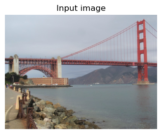

```
Top 5 predictions:
  09.Golden_Gate_Bridge               (prob: 0.66)
  30.Brooklyn_Bridge                  (prob: 0.18)
  28.Sydney_Harbour_Bridge            (prob: 0.06)
  38.Forth_Bridge                     (prob: 0.06)
  26.Pont_du_Gard                     (prob: 0.01)
```

```python
import glob
import torch
from PIL import Image
import torchvision.transforms as T
import matplotlib.pyplot as plt
import numpy as np

# Pick any of the bundled sample images (feel free to change the index or
# point this to any picture on your own computer)
sample_images = sorted(glob.glob("static_images/test/*/*.jpg"))
image_path = sample_images[0]
print(f"Using image: {image_path}")

img = Image.open(image_path).convert("RGB")

# Load the exported TorchScript model (change to original_exported.pt if
# you want to use the from-scratch CNN instead of the transfer-learned one)
learn_inf = torch.jit.load("checkpoints/transfer_exported.pt")

timg = T.ToTensor()(img).unsqueeze_(0)
softmax = learn_inf(timg).data.cpu().numpy().squeeze()

idxs = np.argsort(softmax)[::-1]

plt.figure(figsize=(4, 4))
plt.imshow(img)
plt.axis("off")
plt.title("Input image")
plt.show()

print("Top 5 predictions:")
for i in range(5):
    p = softmax[idxs[i]]
    landmark_name = learn_inf.class_names[idxs[i]]
    print(f"  {landmark_name:35s} (prob: {p:.2f})")
```

## (Stand out) Image retrieval using CNN features

[figure not shown]

As a stand-out exercise, we can use the penultimate-layer features of our CNN (i.e., the features right before the final classification layer) to implement a very simple image-retrieval system: given a query image, find the most visually similar images in our gallery by comparing their CNN features with a dot product.

`MyModel.get_features()` (defined in `src/model.py`) returns exactly these penultimate-layer features. Here we:

1. Load the trained from-scratch model's weights.
2. Extract features for every image in a small gallery (the test split of `landmark_images`).
3. Extract features for a query image.
4. Rank gallery images by dot-product similarity with the query, and show the closest matches.

```
Reusing cached mean and std
```

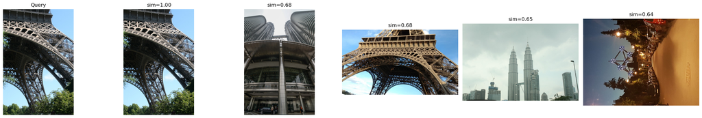

```python
import torch
import torch.nn.functional as F
from pathlib import Path
from PIL import Image
from torchvision import datasets
import torchvision.transforms as T
import matplotlib.pyplot as plt

from src.model import MyModel
from src.helpers import compute_mean_and_std, get_data_location

num_classes = 50  # must match what you used for training

mean, std = compute_mean_and_std()
retrieval_transform = T.Compose([
    T.Resize(256),
    T.CenterCrop(224),
    T.ToTensor(),
    T.Normalize(mean, std),
])

# Load the from-scratch model and its best weights
feature_model = MyModel(num_classes=num_classes, dropout=0.0)
feature_model.load_state_dict(torch.load("checkpoints/best_val_loss.pt", map_location="cpu"))
feature_model.eval()

# Build a small gallery from the test split
gallery_root = Path(get_data_location()) / "test"
gallery_dataset = datasets.ImageFolder(gallery_root, transform=retrieval_transform)

# To keep this fast, use a random subset of the gallery as candidates
n_gallery = min(200, len(gallery_dataset))
gallery_indices = torch.randperm(len(gallery_dataset))[:n_gallery]

gallery_features = []
gallery_paths = []
with torch.no_grad():
    for idx in gallery_indices:
        idx = int(idx)
        img_tensor, _ = gallery_dataset[idx]
        feats = feature_model.get_features(img_tensor.unsqueeze(0))
        gallery_features.append(F.normalize(feats, dim=1))
        gallery_paths.append(gallery_dataset.samples[idx][0])
gallery_features = torch.cat(gallery_features, dim=0)

# Use one of the bundled sample images as the query
query_path = "static_images/test/16.Eiffel_Tower/3828627c8730f160.jpg"
query_img = Image.open(query_path).convert("RGB")
query_tensor = retrieval_transform(query_img).unsqueeze(0)

with torch.no_grad():
    query_features = F.normalize(feature_model.get_features(query_tensor), dim=1)

# Dot product between the (normalized) query features and every gallery image's
# features -- the higher the dot product, the more similar the images are
similarities = (gallery_features @ query_features.T).squeeze()
top_k = 5
top_indices = torch.argsort(similarities, descending=True)[:top_k]

fig, axes = plt.subplots(1, top_k + 1, figsize=(4 * (top_k + 1), 4))
axes[0].imshow(query_img)
axes[0].set_title("Query")
axes[0].axis("off")

for i, idx in enumerate(top_indices):
    match_img = Image.open(gallery_paths[idx]).convert("RGB")
    axes[i + 1].imshow(match_img)
    axes[i + 1].set_title(f"sim={similarities[idx]:.2f}")
    axes[i + 1].axis("off")

plt.tight_layout()
plt.show()
```

## (Stand out) Additional use cases for this model

[figure not shown]

Beyond automatically tagging photos with the depicted landmark, the same landmark classifier (or the CNN-feature image-retrieval approach above) could be useful in several other situations:

- **Automatic photo album organization**: group a user's photos by location/landmark even when GPS metadata is missing (e.g. photos taken in airplane mode, exported from messaging apps that strip EXIF data, or scanned from old prints).
- **Duplicate/near-duplicate detection and "similar photos" suggestions**: the image-retrieval approach above (dot product on CNN features) can power a "more like this" or "find similar photos in your library" feature, which is useful independent of whether the photo depicts a recognized landmark.
- **Travel and tourism apps**: automatically identify a landmark from a tourist's photo and surface related information (history, opening hours, nearby attractions) without requiring the user to type anything.
- **Content moderation / copyright and safety checks**: quickly flag whether user-generated content depicts a specific, recognizable location, which can be relevant for platforms that restrict or review images of certain sensitive sites.
- **Dataset curation for other ML pipelines**: a landmark classifier can be used to automatically label or filter large, unlabeled photo datasets before further downstream analysis (e.g. building improved landmark datasets for future model training).

That said, it's worth being upfront about the current model's limitations: it can only recognize the 50 landmarks it was trained on, will confidently (and incorrectly) classify photos of landmarks it doesn't know as one of those 50, and its accuracy depends heavily on image quality, framing, and how visually distinctive/well-represented a landmark is in the training data.

## (optional) Taking it to the next level

You can run this notebook as a standalone app on your computer by following these steps:

1. Download this notebook in a directory on your machine
2. Download the model export (for example, `checkpoints/transfer_exported.pt`) in a subdirectory called `checkpoints` within the directory where you save the app.ipynb notebook
3. Install voila if you don't have it already (`pip install voila`)
4. Run your app: `voila app.ipynb --show_tracebacks=True`
5. Customize your notebook to make your app prettier and rerun voila

You can also deploy this app as a website using Binder: https://voila.readthedocs.io/en/stable/deploy.html#deployment-on-binder

## Standalone app

See the app.ipynb file, app.html and deployed app screenshot saved as pdf in the project folder